# Projeto básico em Data Science

Edson Nilton de Moura SIlva Júnior

2023-01-12

# 1 Introdução

Para essa apresentação básica em Data Science, serão utilizada funções básicas de tratamento de dados, principalmente com o pacote `tidyverse`, além de análises estatísticas, focando na resolução de problemas envolvendo estratégias de vendas em empresas.

# 2 Pacotes exigidos

Para começar, será carregado o pacote `tidyverse`. Este carrega automaticamente outros pacotes úteis no tratamento de dados, como remoção de dados faltantes (`NA`), manipulação dos dados e a parte de vizualização dos mesmos em plots.

```r
library(tidyverse)
```

# 3 Base de dados utilizada

Será utilizada a base de dados de serviços e clientes da empresa Telecom, através da plataforma online Kaggle.

## 3.1 Carregando a base de dados

```r
telecom <- readr::read_csv("telecom_users.csv")
```

```
## ──────────────────────────────────────────────────────── Delimiter: "," chr
## (17): IDCliente, Genero, Casado, Dependentes, ServicoTelefone, Multiplas... dbl
## (5): ...1, Aposentado, MesesComoCliente, ValorMensal, TotalGasto lgl (1):
## Codigo
```

## 3.2 Vicualizando a base de dados

A base de dados possui 5986 linhas, então com a função `slice_head()`, do pacote `dplyr`, foram carregadas apenas as 30 primeiras linhas.

```r
telecom %>%
  as.data.frame() %>%
  dplyr::slice_head(n = 30)
```

```
##    ...1  IDCliente    Genero Aposentado Casado Dependentes MesesComoCliente
## 1  1869 7010-BRBUU Masculino          0    Sim         Sim               72
## 2  4528 9688-YGXVR  Feminino          0    Nao         Nao               44
## 3  6344 9286-DOJGF  Feminino          1    Sim         Nao               38
## 4  6739 6994-KERXL Masculino          0    Nao         Nao                4
## 5   432 2181-UAESM Masculino          0    Nao         Nao                2
## 6  2215 4312-GVYNH  Feminino          0    Sim         Nao               70
## 7  5260 2495-KZNFB  Feminino          0    Nao         Nao               33
## 8  6001 4367-NHWMM  Feminino          0    Nao         Nao                1
## 9  1480 8898-KASCD Masculino          0    Nao         Nao               39
## 10 5137 8016-NCFVO Masculino          1    Nao         Nao               55
## 11 3169 4578-PHJYZ Masculino          0    Sim         Sim               52
## 12 4653 2091-MJTFX  Feminino          0    Sim         Sim               30
## 13 2850 2277-DJJDL Masculino          1    Sim         Nao               60
## 14 1760 2511-MORQY Masculino          0    Sim         Sim               50
```

[output cut: 140 more lines]

# 4 Questões de análises

Existem algumas observações da coluna de cancelamentos (`Churm`) em que o cliente cancelou o plano. Algumas análises importantes seriam:

1. Calcular a porcentagem desses cancelamentos;
2. Entender se existe uma relação entre as outras variáveis da base de dados com o cancelamento;
3. Baseado nas informações obtidas, propôr estratégias para diminuir a pocentagem de cancelamentos.

Para isso, antes de tudo, é preciso fazer análises exploratória dos dados: explorá-los, para entender possíveis padrões e levantar hipóteses do que pode estar relacionado.

# 5 Análise Exploratórias

## 5.1 Tratamento dos dados

Ao remover todas as linhas sem valores, foi visto que não sobrou nenhuma. Isso significa que, ao longo de toda a base de dados, todas as linhas tem algum dado do tipo `NA`, em alguma das 23 colunas. Isso significa que, para as análises que envolvem remover dados `NA` é necessário antes selcionar apenas as colunas de interesse.

```r
telecom %>%
  na.omit()
```

```
## # A tibble: 0 × 23
## # … with 23 variables: ...1 <dbl>, IDCliente <chr>, Genero <chr>,
## #   Aposentado <dbl>, Casado <chr>, Dependentes <chr>, MesesComoCliente <dbl>,
## #   ServicoTelefone <chr>, MultiplasLinhas <chr>, ServicoInternet <chr>,
## #   ServicoSegurancaOnline <chr>, ServicoBackupOnline <chr>,
## #   ProtecaoEquipamento <chr>, ServicoSuporteTecnico <chr>,
## #   ServicoStreamingTV <chr>, ServicoFilmes <chr>, TipoContrato <chr>,
## #   FaturaDigital <chr>, FormaPagamento <chr>, ValorMensal <dbl>, …
```

## 5.2 média e desvio do `ValorMensal` e `Totalgasto`

```r
telecom %>%
  select(ValorMensal, TotalGasto) %>%
  na.omit() %>%
  summarise(`média do Valor Mensal` = mean(ValorMensal),
            `desvio padrão do Valor Mensal` =  sd(ValorMensal),
            `média do Total gasto` = mean(TotalGasto),
            `desvio padrão do Total gastol` =  sd(TotalGasto))
```

```
## # A tibble: 1 × 4
##   `média do Valor Mensal` `desvio padrão do Valor Mensal` média do Tot…¹ desvi…²
##                     <dbl>                           <dbl>          <dbl>   <dbl>
## 1                    64.8                            30.1          2298.   2274.
## # … with abbreviated variable names ¹`média do Total gasto`,
## #   ²`desvio padrão do Total gastol`
```

## 5.3 Análise Exploratória com gráficos

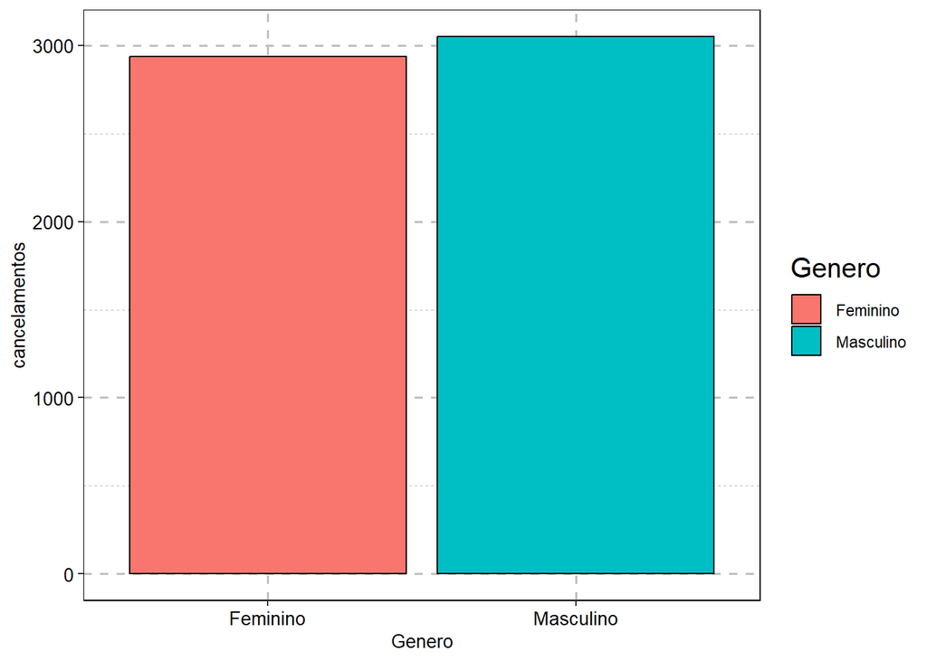

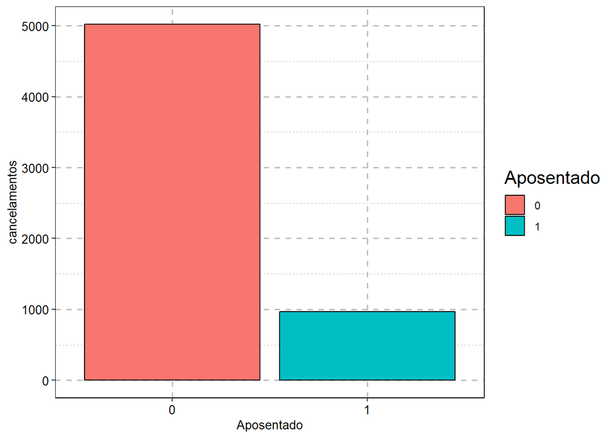

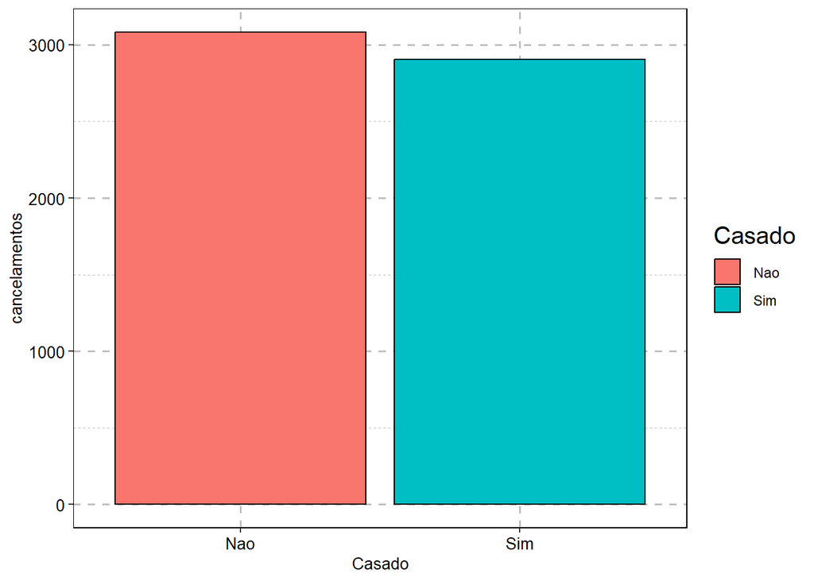

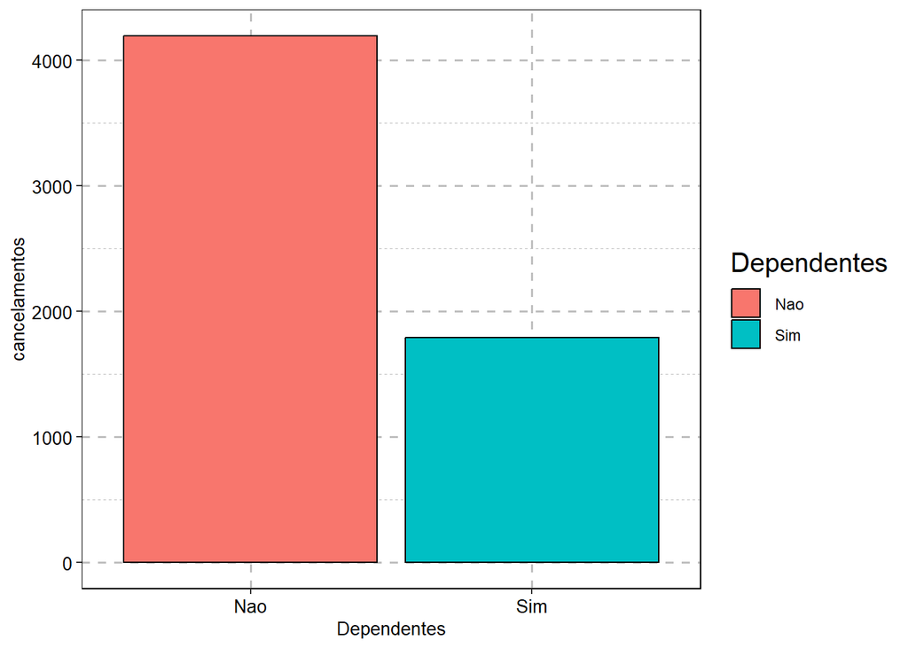

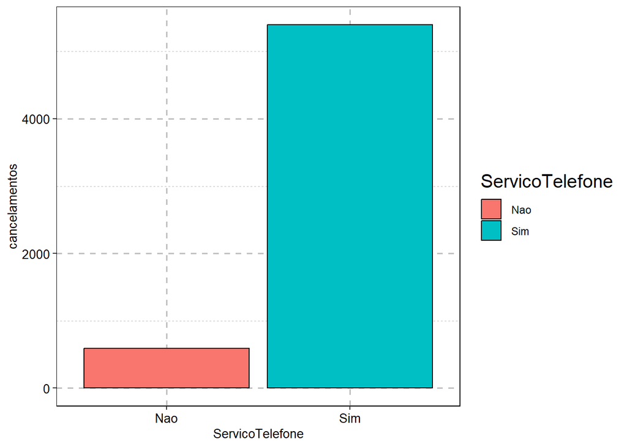

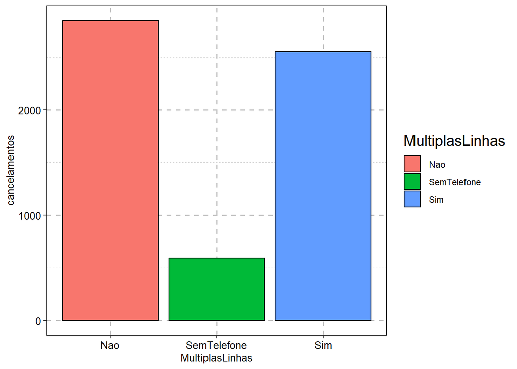

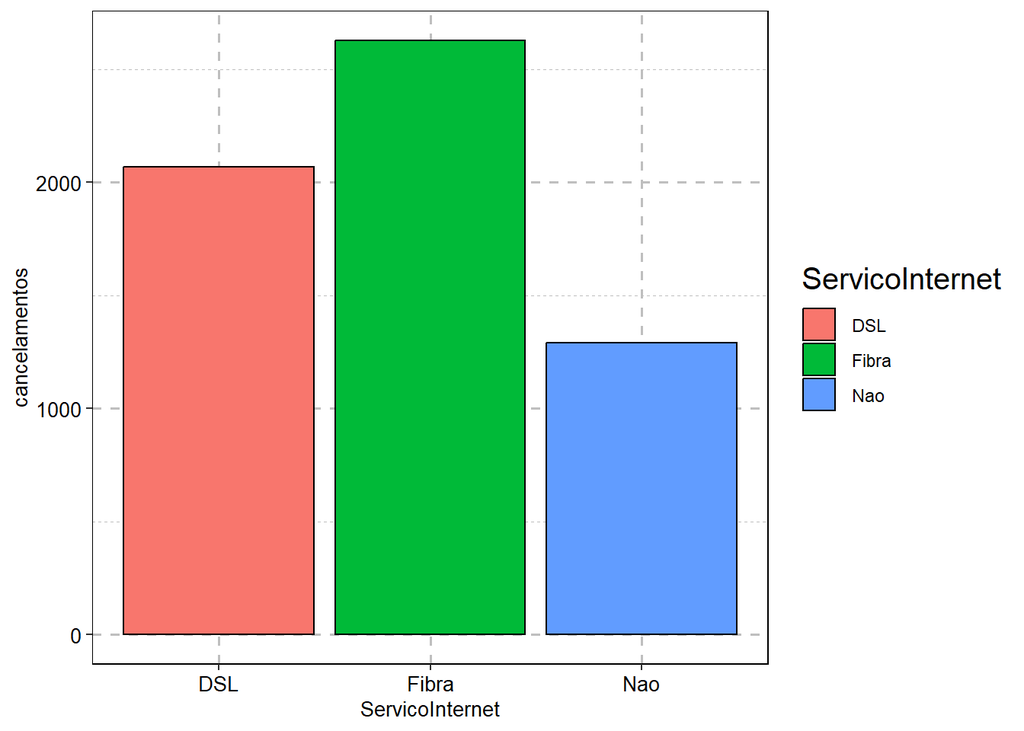

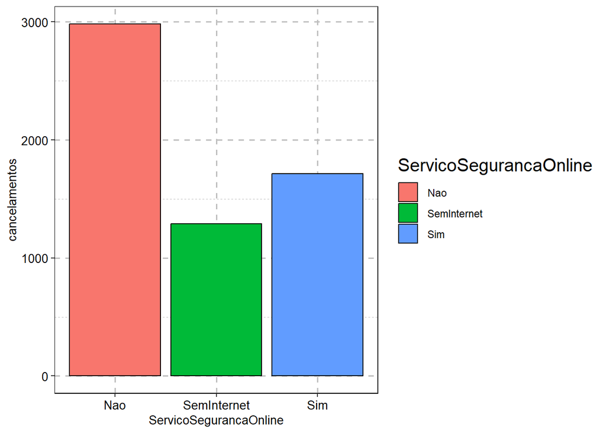

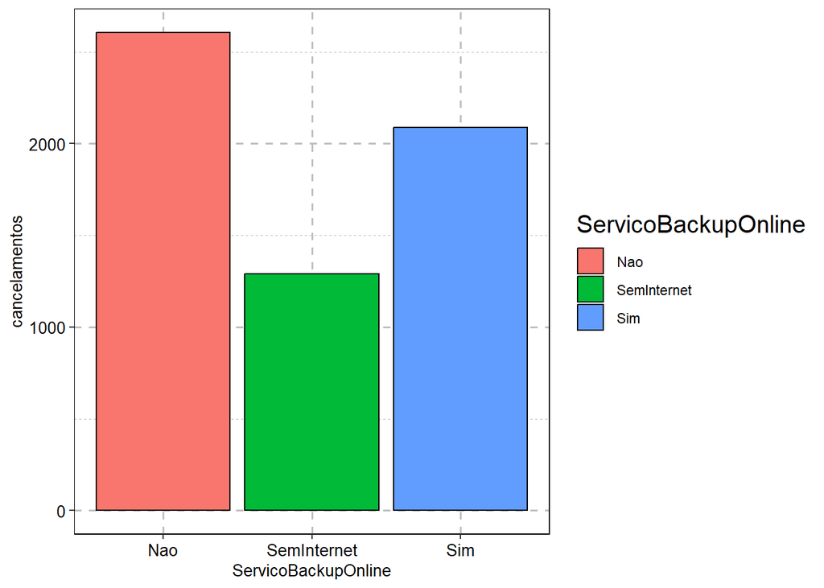

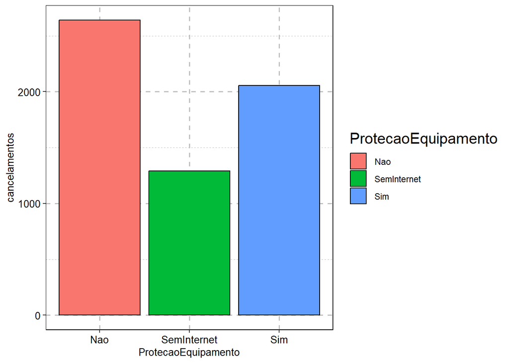

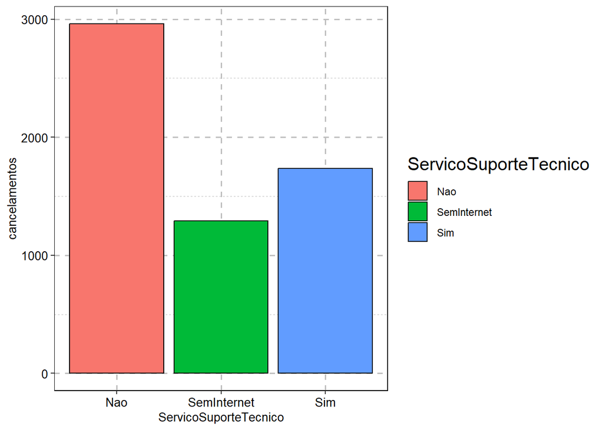

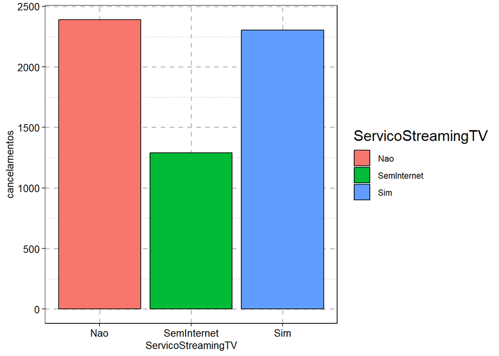

[4 more figures not shown]

```r
telecom$Aposentado <- telecom$Aposentado %>%
  as.factor()

tema <- theme(text=element_text(family="TimesNewRoman"),
            title=element_text(color="black",size=15),
            axis.text = element_text(color="black",size=10),
            axis.title = element_text(color="black",size=10),
            panel.grid=element_line(color="grey75",linetype="dashed",size=0.7),
            axis.line=element_blank(),
            plot.background=element_rect(fill="white",color="white"),
            panel.background=element_rect(fill="white"),
            panel.border = element_rect(colour = "black",fill=NA,size=0.5),
            legend.key= element_rect(color="white",fill="white"))

for(i in telecom[,-c(1:2, 7, 20:23)] %>% names){
  print(telecom %>%
          select(Churn, i) %>%
          na.omit() %>%
          group_by(.data[[i]]) %>%
          summarise(cancelamentos = n(),
                    i = .data[[i]]) %>%
          unique() %>%
          ggplot(aes(i, cancelamentos, fill = i))+
          geom_col(color = "black")+
          labs(x = i,
               fill = i)+
          tema)
}
```

# 6 Análises estatísticas

## 6.1 % de cancelamentos

É possível observar que a taixa de cancelamento está em 26,5%. Não está alta.

```r
telecom %>%
  group_by(Churn) %>%
  summarise(n())
```

```
## # A tibble: 3 × 2
##   Churn `n()`
##   <chr> <int>
## 1 Nao    4398
## 2 Sim    1587
## 3 <NA>      1
```

```r
(1587*100)/5986
```

```
## [1] 26.51186
```

## 6.2 Regressão Logística

A regressão logística é uma técnica que permite testar se uma variável numérica contínua (`variável x`) está influenciando na variação de observações em uma variável categórica (`variável y`). Aqui, ela será usada para testar se o quanto os valores de das varáveis de meses como clientes, o valor mensal do plano e o total gasto pelo cliente (`variável x`) está influenciando na taxa de cancelamento (`variável y`).

```r
Telecom <- telecom %>%
  mutate(Churn = ifelse(telecom$Churn == "Sim", 1, 0))

for(i in telecom[, -c(1, 4)] %>% select_if(is.numeric)){

  print(glm(Churn ~ i, family = binomial(link="logit"), data = Telecom) %>%
  summary())

}
```

```
##
## Call:
## glm(formula = Churn ~ i, family = binomial(link = "logit"), data = Telecom)
##
## Deviance Residuals:
##     Min       1Q   Median       3Q      Max
## -1.1852  -0.8399  -0.4844   1.1858   2.3649
##
## Coefficients:
##              Estimate Std. Error z value Pr(>|z|)
## (Intercept)  0.018390   0.045919    0.40    0.689
## i           -0.038219   0.001516  -25.21   <2e-16 ***
## ---
## Signif. codes:  0 '***' 0.001 '**' 0.01 '*' 0.05 '.' 0.1 ' ' 1
##
## (Dispersion parameter for binomial family taken to be 1)
##
##     Null deviance: 6923.3  on 5984  degrees of freedom
## Residual deviance: 6128.8  on 5983  degrees of freedom
##   (1 observation deleted due to missingness)
## AIC: 6132.8
##
## Number of Fisher Scoring iterations: 4
##
##
## Call:
## glm(formula = Churn ~ i, family = binomial(link = "logit"), data = Telecom)
##
## Deviance Residuals:
##     Min       1Q   Median       3Q      Max
## -1.0668  -0.8486  -0.6640   1.3800   1.9537
##
## Coefficients:
##              Estimate Std. Error z value Pr(>|z|)
## (Intercept) -2.027490   0.079934  -25.36   <2e-16 ***
## i            0.014835   0.001043   14.22   <2e-16 ***
## ---
## Signif. codes:  0 '***' 0.001 '**' 0.01 '*' 0.05 '.' 0.1 ' ' 1
##
## (Dispersion parameter for binomial family taken to be 1)
```

[output cut: 16 more lines]

```
## Coefficients:
##               Estimate Std. Error z value Pr(>|z|)
## (Intercept) -5.498e-01  4.040e-02  -13.61   <2e-16 ***
## i           -2.322e-04  1.567e-05  -14.82   <2e-16 ***
## ---
## Signif. codes:  0 '***' 0.001 '**' 0.01 '*' 0.05 '.' 0.1 ' ' 1
##
## (Dispersion parameter for binomial family taken to be 1)
##
##     Null deviance: 6917.1  on 5974  degrees of freedom
## Residual deviance: 6659.9  on 5973  degrees of freedom
##   (11 observations deleted due to missingness)
## AIC: 6663.9
##
## Number of Fisher Scoring iterations: 4
```

Para exemplificar melhor, será feito gráfico de dispersão (`gráfico de pontos`).

[figure not shown]

[figure not shown]

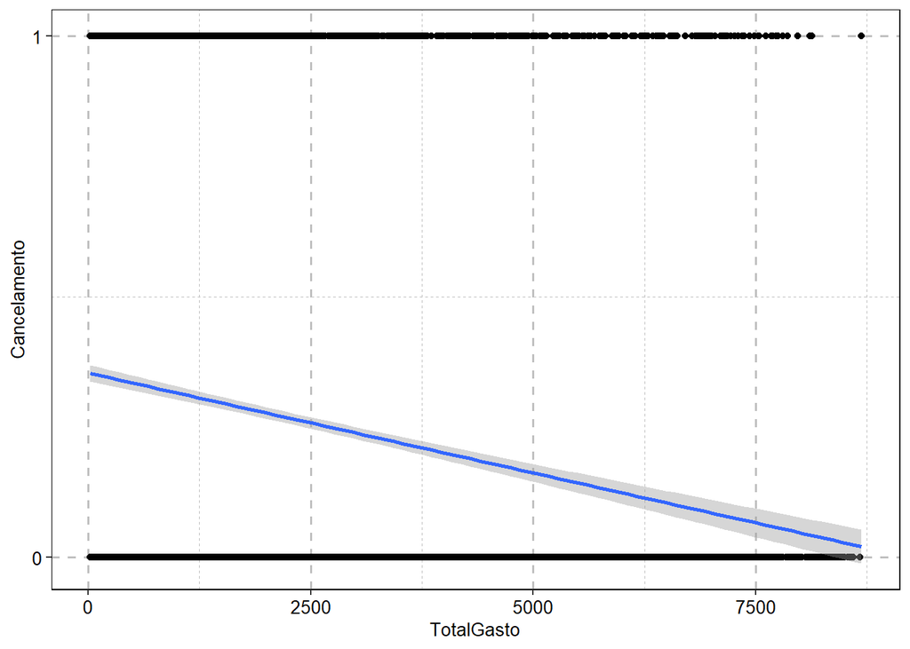

```r
for(i in telecom[, -c(1, 4)] %>% select_if(is.numeric) %>% names){
  for(j in telecom[, -c(1, 4)] %>% select_if(is.numeric)){
  }
  print(Telecom %>%
          ggplot(aes(j, Churn))+
          geom_point()+
          geom_smooth(method = "glm")+
          scale_y_continuous(breaks = seq(0,1,1))+
          labs(x = i,
               y = "Cancelamento")+
          tema)

}
```

# 7 Conclusões

## 7.3 Sugestões de estratégias que podem ser tomadas

Estratégias que poderiam ser adotas seriam:

1. Incluir planos de serviços que abrangegm mais serviços, com menor preço adicional, além de mostrar os benefícios. Uma forma interessante seria um período de teste gratúito;
2. Icentivar planos mais longos, dando descontos, onde, ao longo do período, cada mês estivesse mais barato que planos mensais, podendo envolver benefícios, alguns até acumuláveis. O importante é fazer o cliente permanecer cada vez mais;
3. Icentivar planos família, com mais opções de serviços para diferentes faixas etárias, como planos com segurança e bloqueio de sites nocivoa para crianças;
4. Icentivar o uso de formas de pagamentos não digitais, envolvendo benefícios e praticidades.